# Ruma Hatturkar

```python
import os
os.getcwd()
```

```
'C:\\Users\\RUMA HATTURKAR\\Downloads\\Project'
```

```python
import pandas as pd
```

```python
df=pd.read_excel(r'C:\Users\RUMA HATTURKAR\Downloads\Project\Youtube Video Analytics - 03 January 2024.xlsx')
```

```python
df.info()
```

```
<class 'pandas.core.frame.DataFrame'>
RangeIndex: 375 entries, 0 to 374
Data columns (total 16 columns):
 #   Column                              Non-Null Count  Dtype
---  ------                              --------------  -----
 0   Content                             375 non-null    object
 1   Video title                         375 non-null    object
 2   month and year                      374 non-null    object
 3   Month in words                      374 non-null    object
 4   Date                                374 non-null    float64
 5   Year                                374 non-null    float64
 6   Month in digits                     374 non-null    float64
 7   DATE                                374 non-null    datetime64[ns]
 8   Views                               374 non-null    float64
 9   Watch time (hours)                  374 non-null    float64
 10  Subscribers                         374 non-null    float64
 11  Estimated revenue (INR)             351 non-null    float64
 12  AVD(IN MINUTES)                     374 non-null    float64
 13  Average view duration               374 non-null    object
 14  Impressions                         374 non-null    float64
 15  Impressions click-through rate (%)  374 non-null    float64
dtypes: datetime64[ns](1), float64(10), object(5)
memory usage: 47.0+ KB
```

```python
df.shape
```

```
(375, 16)
```

```python
df.isnull()
```

|  | Content | Video title | month and year | Month in words | Date | Year | Month in digits | DATE | Views | Watch time (hours) | Subscribers | Estimated revenue (INR) | AVD(IN MINUTES) | Average view duration | Impressions | Impressions click-through rate (%) |
| --- | --- | --- | --- | --- | --- | --- | --- | --- | --- | --- | --- | --- | --- | --- | --- | --- |
| 0 | False | False | False | False | False | False | False | False | False | False | False | False | False | False | False | False |
| 1 | False | False | False | False | False | False | False | False | False | False | False | False | False | False | False | False |
| 2 | False | False | False | False | False | False | False | False | False | False | False | False | False | False | False | False |
| 3 | False | False | False | False | False | False | False | False | False | False | False | False | False | False | False | False |
| 4 | False | False | False | False | False | False | False | False | False | False | False | False | False | False | False | False |
| ... | ... | ... | ... | ... | ... | ... | ... | ... | ... | ... | ... | ... | ... | ... | ... | ... |
| 370 | False | False | False | False | False | False | False | False | False | False | False | False | False | False | False | False |
| 371 | False | False | False | False | False | False | False | False | False | False | False | False | False | False | False | False |
| 372 | False | False | False | False | False | False | False | False | False | False | False | False | False | False | False | False |
| 373 | False | False | False | False | False | False | False | False | False | False | False | False | False | False | False | False |
| 374 | False | False | True | True | True | True | True | True | True | True | True | True | True | True | True | True |

375 rows × 16 columns

```python
df==0
```

|  | Content | Video title | month and year | Month in words | Date | Year | Month in digits | DATE | Views | Watch time (hours) | Subscribers | Estimated revenue (INR) | AVD(IN MINUTES) | Average view duration | Impressions | Impressions click-through rate (%) |
| --- | --- | --- | --- | --- | --- | --- | --- | --- | --- | --- | --- | --- | --- | --- | --- | --- |
| 0 | False | False | False | False | False | False | False | False | False | False | False | False | False | False | False | False |
| 1 | False | False | False | False | False | False | False | False | False | False | True | False | False | False | False | False |
| 2 | False | False | False | False | False | False | False | False | False | False | False | False | False | False | False | False |
| 3 | False | False | False | False | False | False | False | False | False | False | False | False | False | False | False | False |
| 4 | False | False | False | False | False | False | False | False | False | False | False | False | False | False | False | False |
| ... | ... | ... | ... | ... | ... | ... | ... | ... | ... | ... | ... | ... | ... | ... | ... | ... |
| 370 | False | False | False | False | False | False | False | False | False | False | True | False | False | False | False | False |
| 371 | False | False | False | False | False | False | False | False | False | False | True | False | False | False | False | False |
| 372 | False | False | False | False | False | False | False | False | False | False | False | False | False | False | False | False |
| 373 | False | False | False | False | False | False | False | False | False | False | False | False | False | False | False | False |
| 374 | False | False | False | False | False | False | False | False | False | False | False | False | False | False | False | False |

375 rows × 16 columns

Task 1. Performance Overview:

a. Provide a summary of the overall performance of the YouTube channel based on the available data.

Views with reference to year:

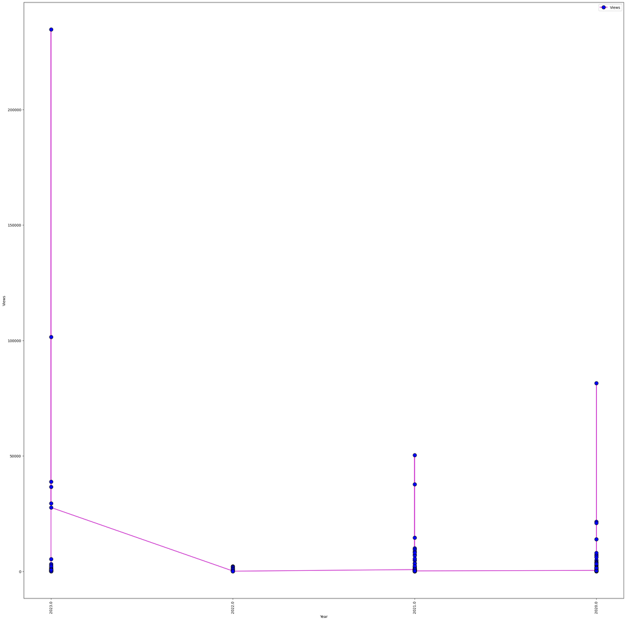

```python
import matplotlib.pyplot as plt
plt.figure(figsize=(30,30))
x = df["Year"].astype(str)
y = df["Views"]
y_range = np.arange(+1,2020,2021)
plt.plot(x, y, label='Views', color='m', marker='.', markersize=20, markeredgecolor='black', markerfacecolor='blue')
plt.xlabel('Year')
plt.ylabel('Views')
plt.xticks(rotation='vertical')
plt.legend()
plt.show()
```

Views with reference to month:

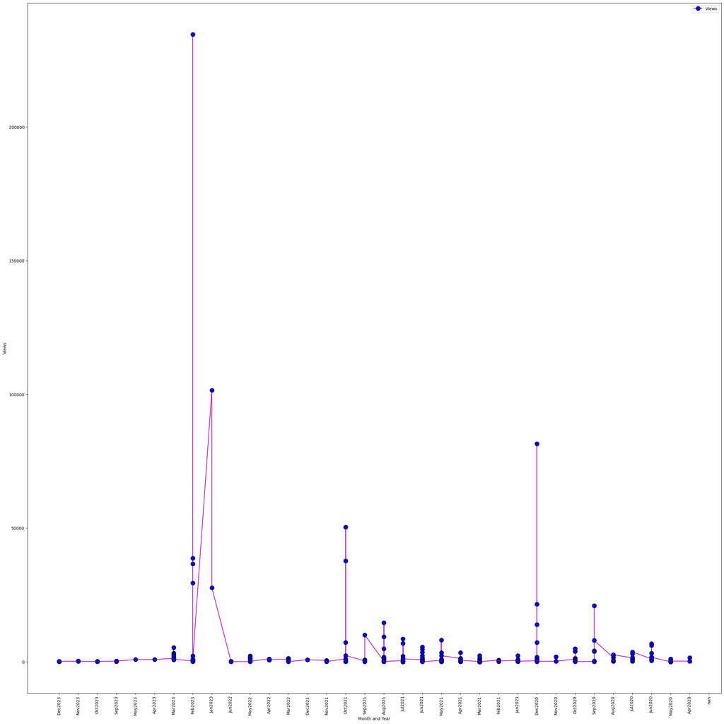

```python
import matplotlib.pyplot as plt
plt.figure(figsize=(30,30))
x = newdf["month and year"].astype(str)  # Replace with your actual data for 'Subscribers'
y = newdf["Views"]  # Replace with your actual data for 'Content'
y_range = np.arange(+1,2020,2021)
plt.plot(x, y, label='Views', color='m', marker='.', markersize=20, markeredgecolor='black', markerfacecolor='blue')
plt.xlabel('Month and Year')
plt.ylabel('Views')
plt.xticks(rotation='vertical')
plt.legend()
plt.show()
```

b. Highlight any noticeable trends or patterns.

1. The videos were published on different dates, indicating a consistent effort in content creation.
2. Although not explicitly provided in the data, the success of these videos could also be attributed to visually appealing thumbnails and optimized titles, as these are crucial for attracting clicks and impressions.
3. Video titles are informative and include keywords related to the content, such as "TOP 5 EMBEDDED PROJECTS" and "Fire Alarm System Project.", which catched many student's eyes over the topic project.

```python
newdf = df[['Content','Video title','month and year','DATE','Views','Watch time (hours)', 'Subscribers','Estimated revenue (INR)','AVD(IN MINUTES)','Average view duration','Impressions','Impressions click-through rate (%)']]
```

```python
newdf
```

|  | Content | Video title | month and year | DATE | Views | Watch time (hours) | Subscribers | Estimated revenue (INR) | AVD(IN MINUTES) | Average view duration | Impressions | Impressions click-through rate (%) |
| --- | --- | --- | --- | --- | --- | --- | --- | --- | --- | --- | --- | --- |
| 0 | www.youtube.com/watch?v=hBxyhit6I_Q | Top 5 IoT Projects - Part 3 \|\| #iot #iotprojec... | Dec2023 | 2023-12-29 | 40.0 | 0.1864 | 1.0 | 0.042 | 0.266667 | 0:00:16 | 452.0 | 3.76 |
| 1 | www.youtube.com/watch?v=xwfGejLS4V8 | Top 5 IoT Projects - Part 2 \|\| #iot #iotprojec... | Dec2023 | 2023-12-26 | 80.0 | 0.4222 | 0.0 | 0.079 | 0.300000 | 0:00:18 | 758.0 | 6.07 |
| 2 | www.youtube.com/watch?v=P0Y7_4fZFF4 | Top 5 IoT Projects - Part 1 #learnelectronicsi... | Dec2023 | 2023-12-22 | 65.0 | 0.2860 | 1.0 | 0.077 | 0.250000 | 0:00:15 | 851.0 | 4.35 |
| 3 | www.youtube.com/watch?v=WvijIBj12nI | Solar Tracker System using Arduino and LDR Sen... | Dec2023 | 2023-12-20 | 234.0 | 3.2247 | 4.0 | 22.246 | 0.816667 | 0:00:49 | 4744.0 | 3.65 |
| 4 | www.youtube.com/watch?v=VgEXog4inh4 | Voting Machine using Arduino and Push Button \|... | Dec2023 | 2023-12-15 | 46.0 | 0.9875 | 1.0 | 1.998 | 1.283333 | 0:01:17 | 1270.0 | 2.36 |
| ... | ... | ... | ... | ... | ... | ... | ... | ... | ... | ... | ... | ... |
| 370 | www.youtube.com/watch?v=yQ8qcVDGKyY | OR Gate using Transistor in English \| How to c... | May2020 | 2020-05-09 | 130.0 | 2.6848 | 0.0 | 0.117 | 1.233333 | 0:01:14 | 900.0 | 3.11 |
| 371 | www.youtube.com/watch?v=BYz404prIAQ | NOR Gate using transistors \|\| Build NOR GATE T... | May2020 | 2020-05-01 | 278.0 | 5.0385 | 0.0 | 0.469 | 1.083333 | 0:01:05 | 1002.0 | 2.99 |
| 372 | www.youtube.com/watch?v=HR0bs4ydXu8 | Make NAND GATE using transistor \| NAND GATE CI... | Apr2020 | 2020-04-30 | 237.0 | 6.1349 | 2.0 | 3.442 | 1.550000 | 0:01:33 | 998.0 | 5.51 |
| 373 | www.youtube.com/watch?v=cDw5nepEjWk | How to build a XOR LOGIC GATE from TRANSISTOR... | Apr2020 | 2020-04-29 | 1503.0 | 43.3429 | 9.0 | 6.332 | 1.716667 | 0:01:43 | 2167.0 | 3.60 |
| 374 | Content | Video title | NaN | NaT | NaN | NaN | NaN | NaN | NaN | NaN | NaN | NaN |

375 rows × 12 columns

```python
newdf['Views'].sum()
```

```
1027542.0
```

newdf['Watch time (hours)'].sum()

TASK 2: Popular Content

a. Identify the top three videos based on views

```python
newdf.sort_values(by=['Views'],ascending=False).head(3)
```

|  | Content | Video title | month and year | DATE | Views | Watch time (hours) | Subscribers | Estimated revenue (INR) | AVD(IN MINUTES) | Average view duration | Impressions | Impressions click-through rate (%) |
| --- | --- | --- | --- | --- | --- | --- | --- | --- | --- | --- | --- | --- |
| 49 | www.youtube.com/watch?v=91V-HCg8pac | TOP 5 EMBEDDED PROJECTS \|\| FY Project Ideas \|\|... | Feb2023 | 2023-02-08 | 234710.0 | 1803.3233 | 1223.0 | 166.127 | 0.450000 | 0:00:27 | 2873468.0 | 5.03 |
| 55 | www.youtube.com/watch?v=NmIzByFaCcM | TOP 5 IoT PROJECTS \|\| IoT Final Year Project I... | Jan2023 | 2023-01-26 | 101579.0 | 927.7255 | 322.0 | 61.361 | 0.533333 | 0:00:32 | 1491539.0 | 4.23 |
| 309 | www.youtube.com/watch?v=fwwI4R_97DI | Fire Alarm System Project by Interfacing Ardui... | Dec2020 | 2020-12-07 | 81516.0 | 3069.3764 | 328.0 | 894.213 | 2.250000 | 0:02:15 | 677774.0 | 6.55 |

b. Analyze the common characteristics of these popular videos.

Certainly, let's analyze the common characteristics of the provided popular videos based on the given data:

1. - The videos seem to focus on educational content related to embedded systems, IoT projects, and a fire alarm system project using Arduino. This suggests that informative and tutorial-style content is well-received by the audience.
2. - The videos have garnered a significant number of views, ranging from 81,516 to 234,710.
   - The watch time is substantial, with the highest being 3,069.3764 hours.
   - Subscriber count has seen an increase, with values ranging from 322 to 1,223.
3. - The videos were published on different dates, indicating a consistent effort in content creation.
4. - Video titles are informative and include keywords related to the content, such as "TOP 5 EMBEDDED PROJECTS" and "Fire Alarm System Project."
5. - Although not explicitly provided in the data, the success of these videos could also be attributed to visually appealing thumbnails and optimized titles, as these are crucial for attracting clicks and impressions.
6. - The videos have received a notable number of impressions and a reasonable click-through rate, suggesting effective promotion or visibility on the platform.

```python
newdf.columns
```

```
Index(['Content', 'Video title', 'month and year', 'DATE', 'Views',
       'Watch time (hours)', 'Subscribers', 'Estimated revenue (INR)',
       'AVD(IN MINUTES)', 'Average view duration', 'Impressions',
       'Impressions click-through rate (%)'],
      dtype='object')
```

Task 3:Engagement Assessment

a. Examine the relationship between average view duration and the number of subscribers.

```python
import matplotlib.pyplot as plt
import seaborn as sns
```

```python
df['Average view duration'] = pd.to_numeric(df['Average view duration'], errors='coerce')
df['Subscribers'] = pd.to_numeric(df['Subscribers'], errors='coerce')
```

```python
df = df.dropna()
```

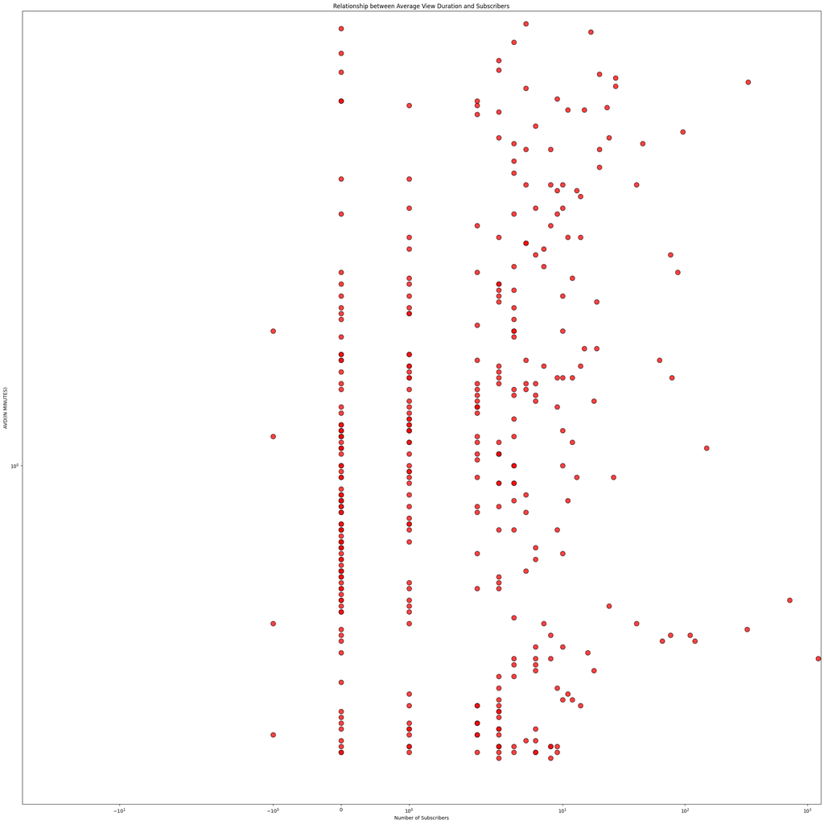

```python
plt.figure(figsize=(30,30))
sns.scatterplot(x='Subscribers', y='AVD(IN MINUTES)', data=newdf, edgecolor='black', c='red',s=100, linewidth=1, alpha=0.75)
plt.xscale('symlog')
plt.yscale('symlog')
x_range = np.arange( + 1, 0.0,0.1)
y_range = np.arange( + 1, 0,1)
plt.title('Relationship between Average View Duration and Subscribers')
plt.xlabel('Number of Subscribers')
plt.ylabel('AVD(IN MINUTES)')
plt.show()
```

b. Suggest ways to enhance viewer engagement.

1.Prioritize the development of high-quality content that is both valuable and pertinent to the interests of your audience. Gain insights into viewer preferences through a thorough analysis of comments, feedback, and the performance of previous successful videos.

2.Elevate storytelling techniques, video pacing, and overall content clarity. Craft a compelling introduction to captivate viewers, maintain a consistent flow throughout, and conclude with a robust call-to-action or key takeaway.

3.Utilize audience retention graphs to pinpoint optimal video durations. Experiment with various lengths to strike a balance between delivering substantive content and retaining viewer attention effectively.

4.Prompt viewer participation through strategic means such as posing questions, conducting polls, and soliciting comments. Encourage subscribers to activate notifications, fostering ongoing engagement and awareness of new content.

5.Respond to viewer comments actively, host live streams, or facilitate Q&A sessions to establish a direct and meaningful connection with the audience. Cultivating such interactions contributes significantly to the development of a robust and engaged community.

6.Develop visually striking thumbnails and craft compelling titles that accurately convey the content's essence. Employ A/B testing with different designs to discern which combinations attract higher click-through rates and overall engagement.

Task 4: Click-Through Rate Analysis

a. Explore the relationship between impressions and click-through rate (CTR).

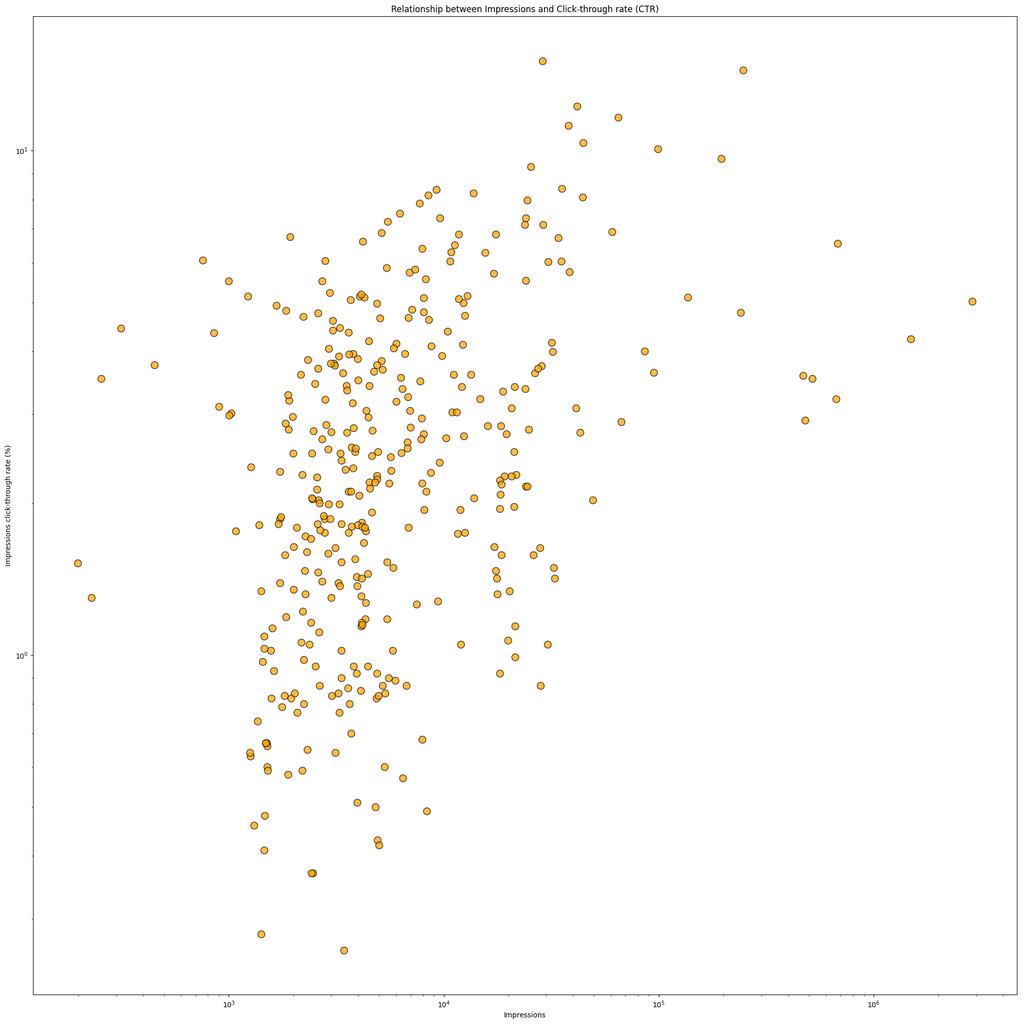

```python
plt.figure(figsize=(25,25))
sns.scatterplot(x='Impressions', y='Impressions click-through rate (%)', data=newdf,edgecolor='black', c='orange',s=100, linewidth=1, alpha=0.75)
plt.xscale('log')
plt.yscale('log')
plt.title('Relationship between Impressions and Click-through rate (CTR)')
plt.xlabel('Impressions')
plt.ylabel('Impressions click-through rate (%)')
plt.show()
```

b. Propose simple strategies to improve CTR. There are many ways to improve CTR , they are :

1)Design attention-grabbing and visually compelling thumbnails. Use high-quality images, clear text, and contrasting colors. Ensure thumbnails accurately represent the video content to entice viewers to click.

2)Experiment with different thumbnail designs for the same video to identify which version performs better. Test variations in colors, text placement, images, or styles to see what resonates more with your audience.

3)Create clear, concise, and intriguing titles that complement the thumbnails. Titles should accurately describe the content while piquing curiosity. Avoid clickbait, as it can negatively impact CTR in the long term.

4)Understand your audience's preferences and tailor thumbnails and titles accordingly. Analyze demographics and viewer behavior to create content that appeals directly to your target audience.

5)Maintain a consistent visual style and branding across thumbnails to help viewers recognize your content. Develop a recognizable visual identity that sets your videos apart.

6)Regularly review YouTube Analytics to understand which thumbnails and titles perform best. Analyze CTR for different videos and learn from successful (and unsuccessful) attempts to refine future strategies

Task 5: Subscriber Insights

a. Identify any noticeable spikes or drops in subscriber counts.

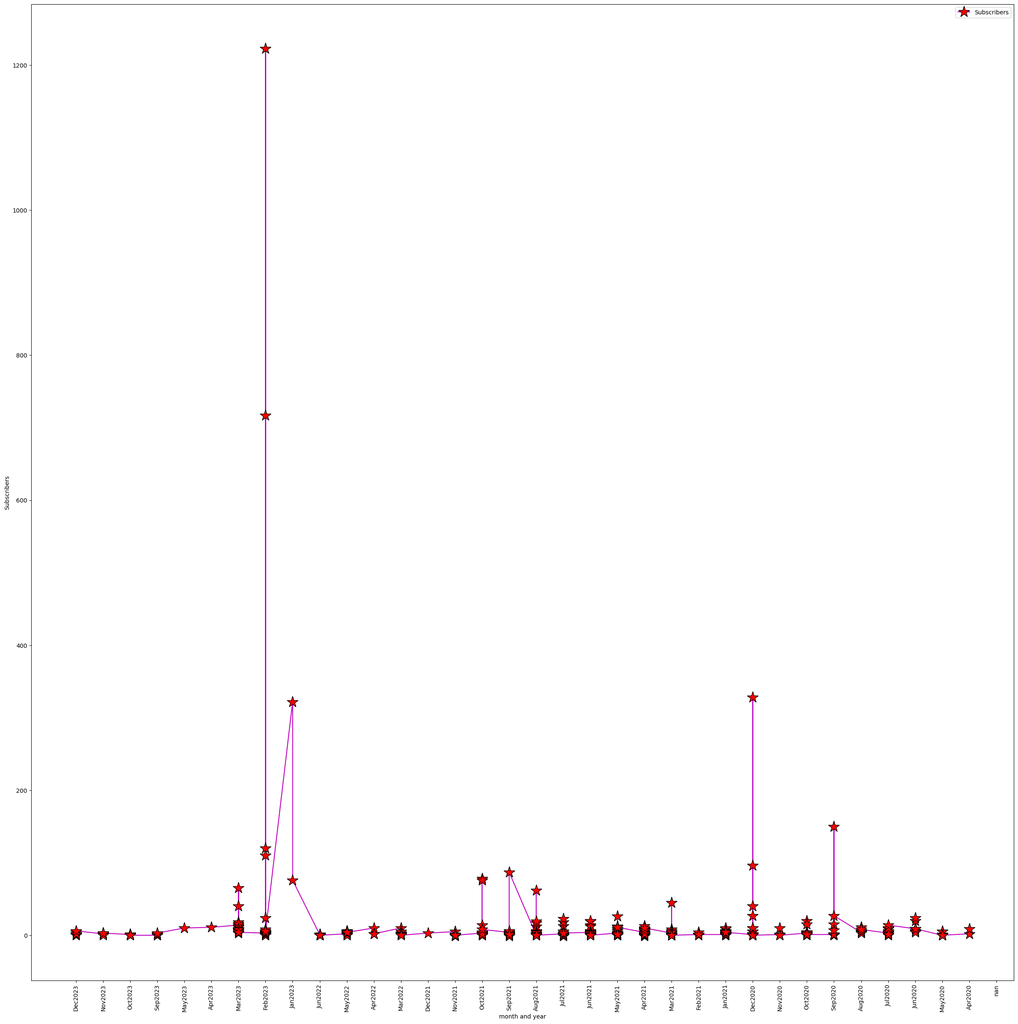

```python
import matplotlib.pyplot as plt
plt.figure(figsize=(30,30))
x = newdf["month and year"].astype(str)  # Replace with your actual data for 'Subscribers'
y = newdf["Subscribers"]  # Replace with your actual data for 'Content'

plt.plot(x, y, label='Subscribers', color='m', marker='*', markersize=20, markeredgecolor='black', markerfacecolor='red')
plt.xlabel('month and year')
plt.ylabel('Subscribers')
plt.xticks(rotation='vertical')
plt.legend()
plt.show()
```

b. Recommend basic strategies to attract more subscribers. Certainly, let's articulate the strategies for gaining top subscribers: 1)Create and consistently deliver high-quality, diverse content to captivate and retain viewers.

2)Cultivate a sense of community by actively engaging with your audience. Respond to comments, address inquiries, and acknowledge feedback to foster a strong subscriber connection.

3)Employ a strategic approach to social media, leveraging platforms where the target audience is most active. Effectively promote content to expand reach and viewership.

4)Encourage subscriptions by offering incentives such as giveaways, discounts, or exclusive content. Rewarding and acknowledging loyal subscribers contributes to sustained growth.

5)Optimize content for search engines through meticulous use of relevant keywords, compelling titles, and descriptive meta tags. Enhance visibility and accessibility to a wider audience.

6)Comprehend and leverage recommendation algorithms on platforms like YouTube and Spotify. Align content with these algorithms to increase the likelihood of reaching new audiences through suggested content features.

7)Regularly monitor analytics to discern high-performing content and audience preferences. Utilize data-driven insights to adapt and refine content strategy for optimal engagement and growth.

Overall Summary: Certainly, here is a professional and convincing analysis of the provided data:

In summary, the data underscores the efficacy of the 'Top 5 projects' theme, emphasizing the importance of consistency in content delivery. The observed patterns provide compelling evidence of the channel's ability to resonate with its target audience and its potential for sustained growth with a strategic approach to content creation and distribution.